# Local Explanations of Breast Cancer Severity Models using SHAP

The UCI ML Breast Cancer Wisconsin dataset, provided in sci-kit learn package, was created based on results of FNA procedure which 569 patients underwent to asses the severity of their breast cancer. Because the FNA procedure results in an image, the experts encoded 30 variables out of it to create tabular data. Detailed information, including simple exploratory analysis and modelling, can be found in [previous report on this topic](https://github.com/MI2-Education/InterpretableMachineLearning2022/blob/main/Homeworks/HW1/ZuzannaKwiatkowska/zuzanna_kwiatkowska_report.ipynb) or [Sci-Kit Learn Documentation](https://scikit-learn.org/stable/datasets/toy_dataset.html#breast-cancer-dataset).

The target variable in this dataset is binary, meaning it encodes:

- patients with malignant tumor as 0,
- patients with benign tumor as 1,

and there are no other classes of interest present in this task.

The aim of this report is to:

- create 2 simple models for solving the task (including 1 tree based),
- explain the predictions of the model locally using SHAP.

Sections 1-3 are done using solely an xgboost models, whereas in section 4 I compare xgboost to multi-layered perceptron model.

## 1. Local explanation of distinctive prediction cases

In this section I decided to analyse explanations from 3 distinctive cases:

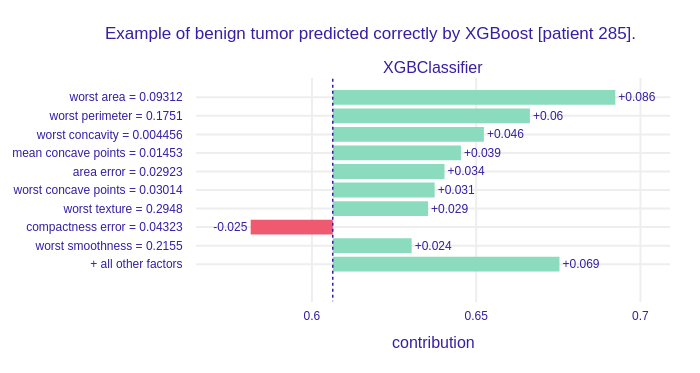

The first interesting information we can derive from the plot is that *worst* type features are high contributors for this particular prediction. For recollection, in the previous report I found out that *worst* type features have no dependency with target variable whatsoever (in a global sense), and yet there are examples that actually need them for confident prediction.

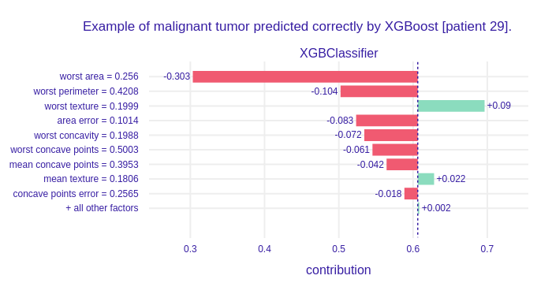

Similar behaviour can be observed for this example of correct malignant tumor prediction. Moreover, *worst area* feature shows a high predictive power in this case. This observation can also lead us to hypothesis that tumors with enlarged cells (in this case *worst area* is the area of the largest cell) may be a sign of malignant tumor or fast tumor growth, which could be consulted with a domain expert in the further iterations of ML model implementation.

## 2. Analysing features of highest importance across predictions

Another observation we can derive from local explanations is the fact that there are no consistent "most important" features in predictions of examples. In section 1, we saw the examples in which *worst area* and *worst perimeter* were the ones with highest contribution, and yet there are also examples that surprisingly use *worst texture* or *mean/worst concave points* as indicator of specific type of tumor.

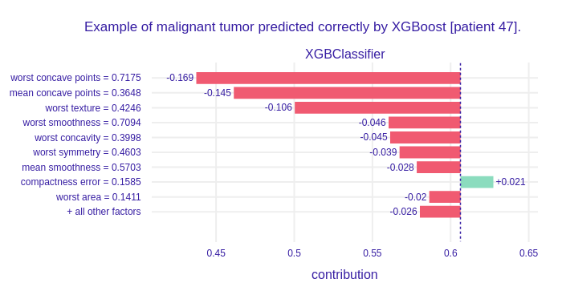

An interesting hypothesis that I can derive here is the question of importance of feature selection in the problems of high imbalance in target variable. Although many of those features did not have any global dependence or correlation with target variable, they seem to be of high importance in classification of malignant tumors which are generally less represented in the dataset. The example of patient 47 (above) is particularly interesting because it uses a rare combination of high important features (which could indicate it might be a problematic example and keeping all the features without selection actually helped in correct classification).

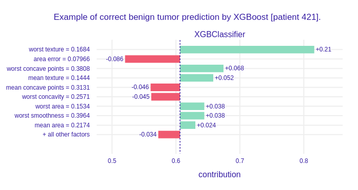

## 3. Analysing contribution mismatch within same feature

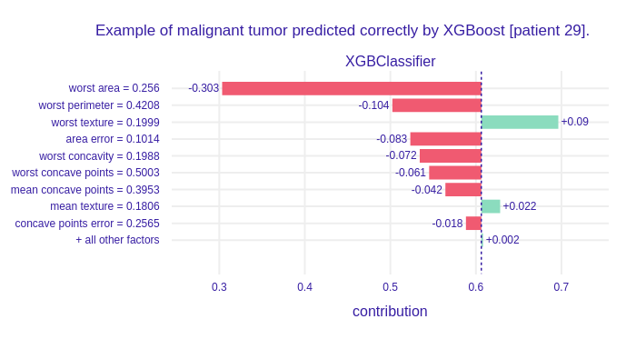

## 4. Analysing feature contribution across models

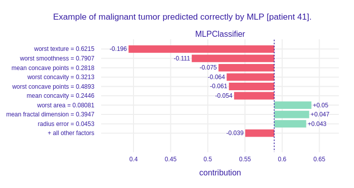

## Closing remarks

Local analysis of model predictions using SHAP allowed us to uncover some interesting hypothesis about the data.

The most crucial one for me is the question of using feature selection in a scenario of high imbalance. SHAP analysis uncovered that in many cases, even if the feature did not have any global correlation or dependency with target variable, it was necessary for correct classification of more complex examples (that often were also of higher interest because they were malignant cases).

Moreover, for example for patient 47, SHAP uncovered a very rare combination of contributing features (with respect to other combinations from other examples), which could be analysed further by domain experts to get more insights about the dataset.

Finally, the analysis could give us some ideas for creating new features. For example, locally in multiple examples, *worst area* of cells is a high contributing indicator for malignant/benign discrimination, which could maybe suggest a faster/slower growth of a tumor and hence the prediction. It could be verified, with the help of domain expert, if a new growth-related proxy feature could be also helpful in further model creation.